# Assignment 4 - Tidy data

2030071 - 1753320

Group 50: Romée Simons and Tycho Brouwer

2024-03-12

# Task 1

For importing the data set, **;** was used as the delimiter, the first 4 lines were skipped, and the final line was skipped by setting the maximum lines read.

Also, the decimal mark was correctly set by setting the locale using the **,** decimal mark.

The data for the **Subject**, the years, are in the character format because they where recognized as the column titles.

The column containing the value **scale** for all it’s entries is missing a column title.

The column names should be **Subject**, **Year**, **Score**, and **ScoreType**.

```r
happiness_data <- read_delim(
  'dataset_happiness.csv',
  delim=";",
  show_col_types = FALSE,
  skip = 4,
  n_max = 6,
  locale=locale(decimal_mark = ",")
  ) |> glimpse()
```

```
## Rows: 6
## Columns: 12
## $ Subject <chr> "OverallHappinessScore", "DailyActivitiesSatisfactionScore", "…
## $ ...2    <chr> "scale", "scale", "scale", "scale", "scale", "scale"
## $ `2013`  <dbl> 7.8, 7.2, 7.7, 8.1, 7.9, 7.3
## $ `2014`  <dbl> 7.7, 7.1, 7.6, 8.0, 7.8, 7.3
## $ `2015`  <dbl> 7.7, 7.3, 7.6, 7.9, 7.8, 7.2
## $ `2016`  <dbl> 7.7, 7.2, 7.5, 7.9, 7.8, 7.2
## $ `2017`  <dbl> 7.7, 7.2, 7.5, 7.8, 7.8, 7.1
## $ `2018`  <dbl> 7.6, 7.3, 7.6, 7.7, 7.8, 7.1
## $ `2019`  <dbl> 7.5, 7.1, 7.6, 7.6, 7.8, 7.2
## $ `2020`  <dbl> 7.4, 7.2, 7.4, 7.3, 7.5, 7.1
## $ `2021`  <dbl> 7.3, 6.9, 7.3, 7.0, 7.2, 7.1
## $ `2022`  <dbl> 7.3, 7.1, 7.6, 7.2, 7.3, 6.9
```

# Task 2

```r
happiness_data_long <- happiness_data |>
  pivot_longer(cols = `2013`:`2022`,
               names_to = "Year",
               values_to = "Score") |>
  rename(c("...2"="ScoreType")) |>
  glimpse()
```

```
## Rows: 60
## Columns: 4
## $ Subject   <chr> "OverallHappinessScore", "OverallHappinessScore", "OverallHa…
## $ ScoreType <chr> "scale", "scale", "scale", "scale", "scale", "scale", "scale…
## $ Year      <chr> "2013", "2014", "2015", "2016", "2017", "2018", "2019", "202…
## $ Score     <dbl> 7.8, 7.7, 7.7, 7.7, 7.7, 7.6, 7.5, 7.4, 7.3, 7.3, 7.2, 7.1, …
```

# Task 3

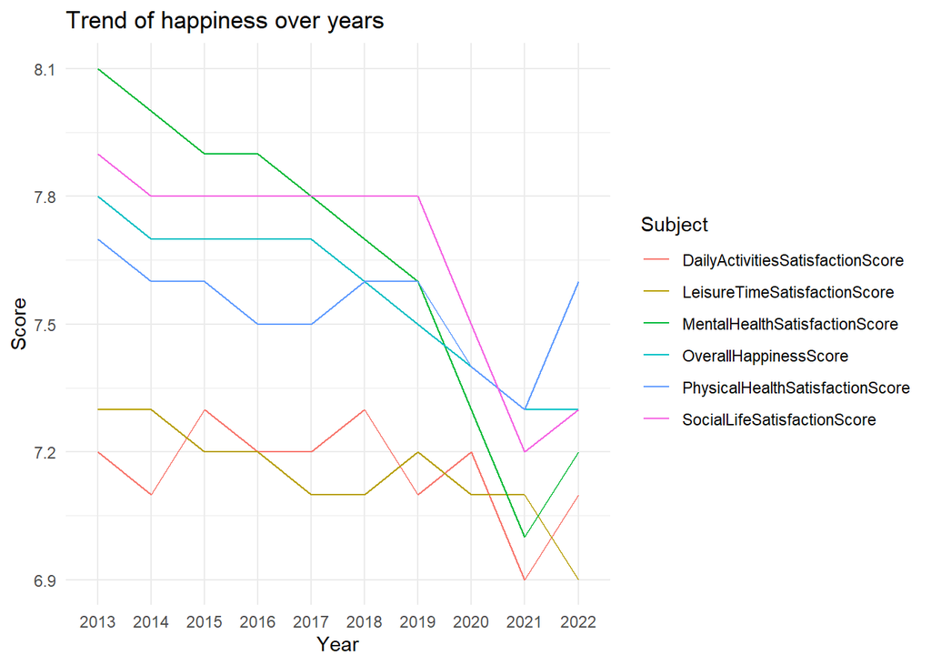

```r
happiness_data_long |>
  ggplot(aes(Year, Score, colour = Subject, group = Subject)) +
  geom_path() +
  ggtitle("Trend of happiness over years") +
   theme_minimal()
```

# Task 4

```r
temp_data_wide <- read_delim(
  'data_temp_wide.csv',
  show_col_types = FALSE,
  delim = ","
  )

head(temp_data_wide, 5)
```

```
## # A tibble: 5 × 4
##   `date [mm-dd]` city_lower     city_mean      city_upper
##   <chr>          <chr>          <chr>          <chr>
## 1 01-01          Eindhoven_0.20 Eindhoven_7.08 Eindhoven_13.96
## 2 01-01          Rotterdam_1.84 Rotterdam_7.56 Rotterdam_13.28
## 3 01-01          Vlieland_3.17  Vlieland_7.38  Vlieland_11.59
## 4 01-02          Eindhoven_3.04 Eindhoven_7.18 Eindhoven_11.32
## 5 01-02          Rotterdam_3.81 Rotterdam_7.35 Rotterdam_10.89
```

```r
glimpse(temp_data_wide)
```

```
## Rows: 1,098
## Columns: 4
## $ `date [mm-dd]` <chr> "01-01", "01-01", "01-01", "01-02", "01-02", "01-02", "…
## $ city_lower     <chr> "Eindhoven_0.20", "Rotterdam_1.84", "Vlieland_3.17", "E…
## $ city_mean      <chr> "Eindhoven_7.08", "Rotterdam_7.56", "Vlieland_7.38", "E…
## $ city_upper     <chr> "Eindhoven_13.96", "Rotterdam_13.28", "Vlieland_11.59",…
```

# Task 5

```r
temp_data_wide |>
  pivot_longer(
    cols = city_lower:city_upper,
    names_to = c("ValueType"),
    names_prefix = "city_",
    values_to = "Temp"
  ) |> glimpse()
```

```
## Rows: 3,294
## Columns: 3
## $ `date [mm-dd]` <chr> "01-01", "01-01", "01-01", "01-01", "01-01", "01-01", "…
## $ ValueType      <chr> "lower", "mean", "upper", "lower", "mean", "upper", "lo…
## $ Temp           <chr> "Eindhoven_0.20", "Eindhoven_7.08", "Eindhoven_13.96", …
```

# Task 6

```r
temp_data_separated <- temp_data_wide |>
  pivot_longer(
    cols = city_lower:city_upper,
    names_to = c("ValueType"),
    names_prefix = "city_",
    values_to = "Temp"
  ) |>
  separate(col=`Temp`, into = c("City", "Temp"), sep = "_", convert = TRUE) |>
  glimpse()
```

```
## Rows: 3,294
## Columns: 4
## $ `date [mm-dd]` <chr> "01-01", "01-01", "01-01", "01-01", "01-01", "01-01", "…
## $ ValueType      <chr> "lower", "mean", "upper", "lower", "mean", "upper", "lo…
## $ City           <chr> "Eindhoven", "Eindhoven", "Eindhoven", "Rotterdam", "Ro…
## $ Temp           <dbl> 0.20, 7.08, 13.96, 1.84, 7.56, 13.28, 3.17, 7.38, 11.59…
```

# Task 7

From the plots it can be seen that for all three cities Eindhoven, Rotterdam, and Vlieland the temperature is at its lowest from December to February. Eindhoven has both the coldest day in the winter and hottest day in the summer of the three cities. From the slope of the temperature, it can be seen that the temperature rises slower in the spring than it declines in the fall. Finally, in none of the cities the temperature is consistenly below 0 degrees in the winter.

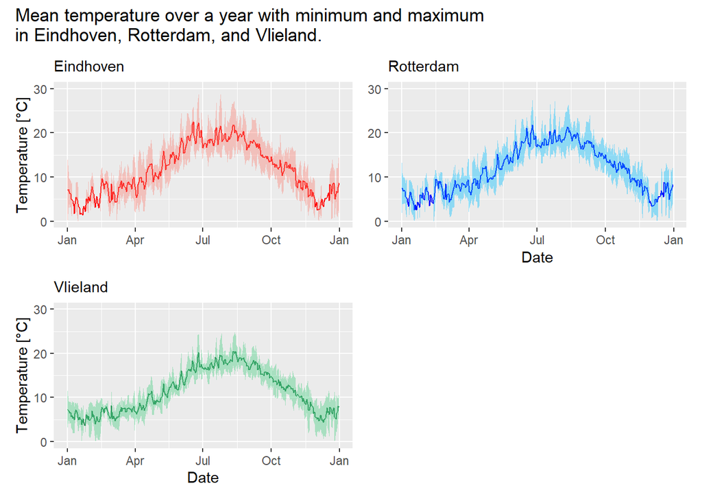